# Лабораторная работа №12

Основы администрирования операционных систем

Верниковская Е. А., НПИбд-01-23

Российский университет дружбы народов, Москва, Россия

19 ноября 2024

# Вводная часть

## Цель работы

Получить навыки настройки сетевых параметров системы.

## Задание

1. Продемонстрировать навыки использования утилиты ip
2. Продемонстрировать навыки использования утилиты nmcli

# Выполнение лабораторной работы

## Проверка конфигурации сети

Запускаем терминала и получаем полномочия суперпользователя, используя *su -* (рис. 1)

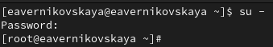

Режим суперпользователя

## Проверка конфигурации сети

Выведим на экран информацию о существующих сетевых подключениях, а также статистику о количестве отправленных пакетов и связанных с ними сообщениях об ошибках: *ip -s link* (рис. 2)

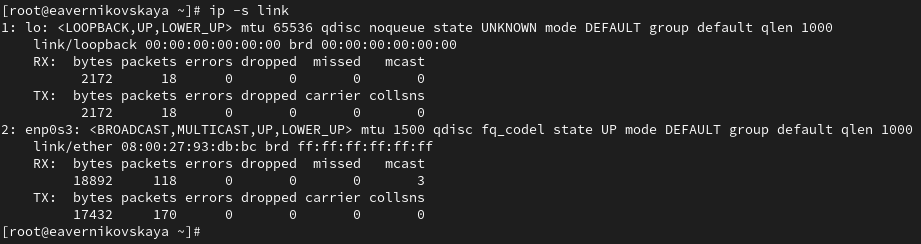

Информация о существующих сетевых подключениях

## Проверка конфигурации сети

Выведим на экран информацию о текущих маршрутах: *ip route show* (рис. 3)

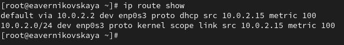

Информация о текущих маршрутах

## Проверка конфигурации сети

Выведим на экран информацию о текущих назначениях адресов для сетевых интерфейсов на устройстве: *ip addr show* (рис. 4)

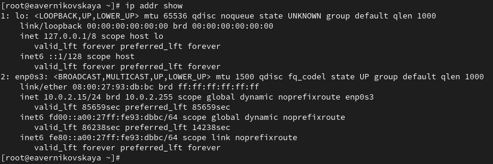

Информация о текущих назначениях адресов для сетевых интерфейсов на устройстве

## Проверка конфигурации сети

Далее используем команду ping для проверки правильности подключения к Интернету. Например, для отправки четырёх пакетов на IP-адрес 8.8.8.8 введём *ping -c 4 8.8.8.8* (рис. 5)

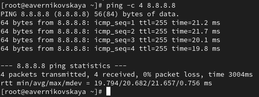

Отправка четырёх пакетов на IP-адрес 8.8.8.8

## Проверка конфигурации сети

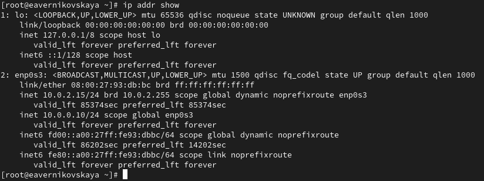

Проверка добавлнеия адреса

## Проверка конфигурации сети

Теперь сравним вывод информации от утилиты *ip* и от команды *ifconfig* (рис. 8), (рис. 9)

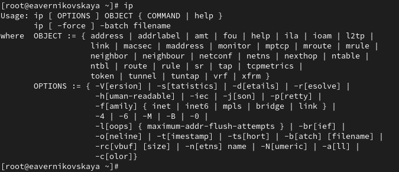

Вывод информации от утилиты ip

## Проверка конфигурации сети

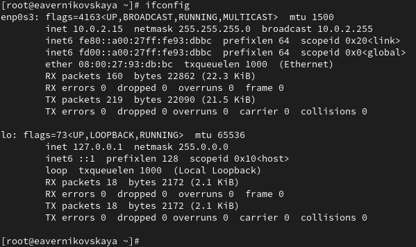

Вывод информации от команды ifconfig

## Проверка конфигурации сети

Выведим на экран список всех прослушиваемых системой портов UDP и TCP: *ss -tul* (рис. 10)

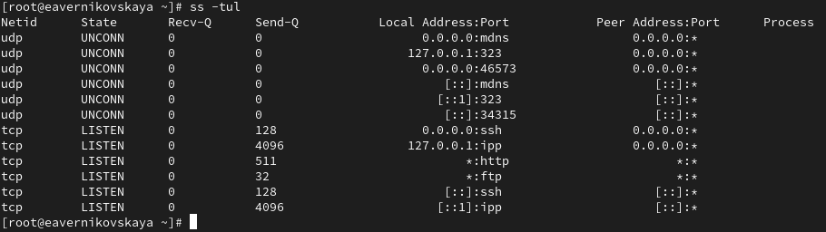

Список всех прослушиваемых системой портов UDP и TCP

## Управление сетевыми подключениями с помощью nmcli

Выведим на экран информацию о текущих соединениях: *nmcli connection show* (рис. 11)

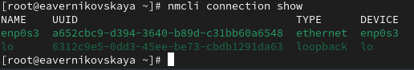

Информация о текущих соединениях (1)

## Управление сетевыми подключениями с помощью nmcli

Добавим Ethernet-соединение с именем dhcp к интерфейсу: *nmcli connection add con-name “dhcp” type ethernet ifname ifname*. Здесь вместо *ifname* должно быть указано название интерфейса. В нашем случае это enp0s3 (рис. 12)

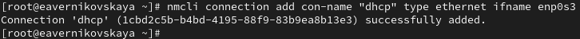

Добавление Ethernet-соединения с именем dhcp

## Управление сетевыми подключениями с помощью nmcli

Теперь добавим к этому же интерфейсу Ethernet-соединение с именем static, статическим IPv4-адресом адаптера и статическим адресом шлюза: *nmcli connection add con-name “static” ifname ifname autoconnect no type ethernet ip4 10.0.0.10/24 gw4 10.0.0.1 ifname ifname* (рис. 13)

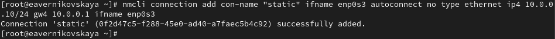

Добавление Ethernet-соединения с именем static

## Управление сетевыми подключениями с помощью nmcli

Снова выведим информацию о текущих соединениях: *nmcli connection show* (рис. 14)

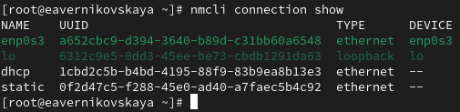

Информация о текущих соединениях (2)

## Управление сетевыми подключениями с помощью nmcli

Переключимся на статическое соединение: *nmcli connection up “static”* (рис. 15)

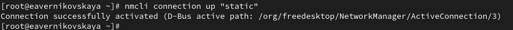

Переключение на статическое соединение

## Управление сетевыми подключениями с помощью nmcli

Проверим успешность переключения при помощи *nmcli connection show* и *ip addr* (рис. 16), (рис. 17)

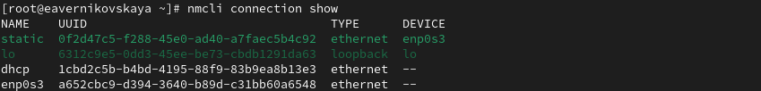

Проверка успешного переключения при помощи nmcli connection show (1)

## Управление сетевыми подключениями с помощью nmcli

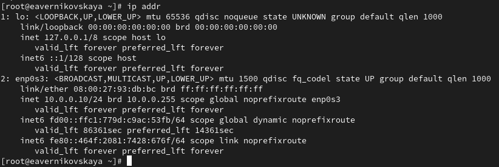

Проверка успешного переключения при помощи ip addr (1)

## Управление сетевыми подключениями с помощью nmcli

Вернёмся к соединению dhcp: *nmcli connection up “dhcp”* (рис. 18)

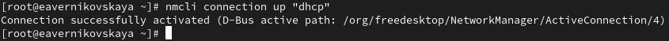

Переключение на соединение dhcp

## Управление сетевыми подключениями с помощью nmcli

Снова проверим успешность переключения при помощи *nmcli connection show* и *ip addr* (рис. 19), (рис. 20)

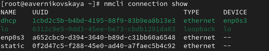

Проверка успешного переключения при помощи nmcli connection show (2)

## Управление сетевыми подключениями с помощью nmcli

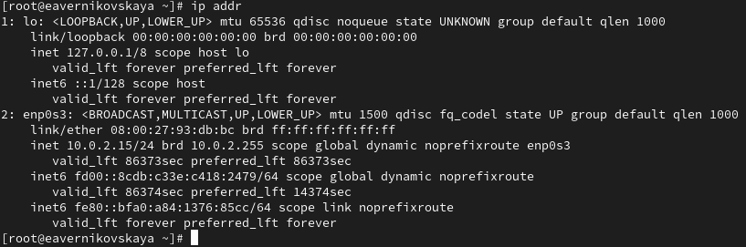

Проверка успешного переключения при помощи ip addr (2)

## Изменение параметров соединения с помощью nmcli

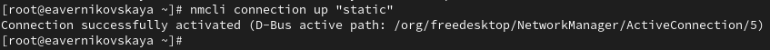

Активирование соединения static

## Изменение параметров соединения с помощью nmcli

Проверим успешность переключения при помощи *nmcli con show* и *ip addr* (рис. 27), (рис. 28)

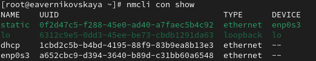

Проверка успешного переключения при помощи nmcli con show (3)

## Изменение параметров соединения с помощью nmcli

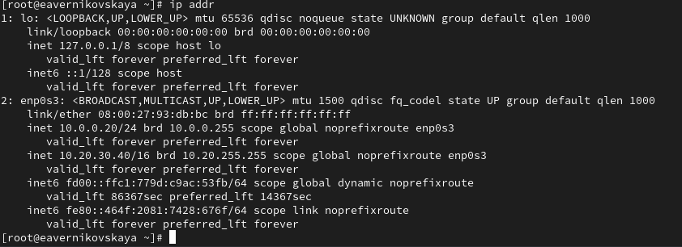

Проверка успешного переключения при помощи ip addr (3)

## Изменение параметров соединения с помощью nmcli

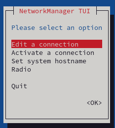

Грфический интерфейс операционной системы

## Изменение параметров соединения с помощью nmcli

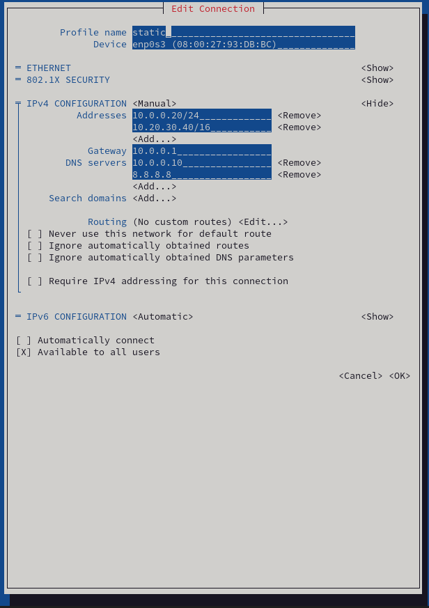

Настройки сетевого соединения static

## Изменение параметров соединения с помощью nmcli

Переключимся на первоначальное сетевое соединение: *nmcli connection up “ifname”*. В нашем случае на enp0s3 (рис. 32)

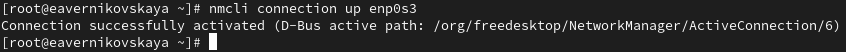

Переключение на первоначальное сетевое соединение

## Изменение параметров соединения с помощью nmcli

Проверим успешность переключения при помощи *nmcli connection show* и *ip addr* (рис. 33), (рис. 34)

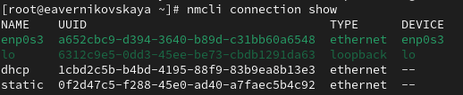

Проверка успешного переключения при помощи nmcli connection show (4)

## Изменение параметров соединения с помощью nmcli

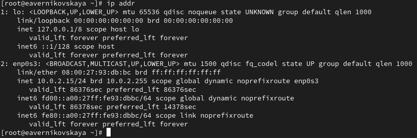

Проверка успешного переключения при помощи ip addr (4)

# Подведение итогов

## Выводы

В ходе выполнения лабораторной работы мы получили навыки настройки сетевых параметров системы

## Список литературы

1. Лаборатораня работа №12 [Электронный ресурс] URL: https://esystem.rudn.ru/pluginfile.php/2400741/mod_resource/content/4/013-network.pdf